# DATA2002-W13A-Early-9

Group Project

480320449

University of Sydney | DATA2002 | 4/11/2020

# 1 Include the libraries, read and transform the data

```r
library(tidyverse)
library(sjPlot)
library(caret)
library(ggpubr)
data = read_tsv("bodyfat.txt")
## Data cleaning
## Change Height from inches to cm by
data$Height <- data$Height*2.54

## Change weight from pounds to kg
data$Weight <-  data$Weight/2.20462
max(data$Weight)
```

```
## [1] 119.1815
```

# 2 Appropriate model selection

## 2.1 Create null model and full model

```r
# names(data)
M0 = lm(Pct.BF ~ 1, data)  # Null model
M1 = lm(Pct.BF ~ ., data)  # Full model

step.back.aic = step(M1,
                    direction = "backward",
                    trace = FALSE)

step.fwd.aic = step(M0, scope = list(lower = M0, upper = M1), direction = "forward", trace = FALSE)
```

```r
## The below code only outputs if knitted!
sjPlot::tab_model( step.fwd.aic, step.back.aic,
 show.ci = FALSE,
 show.aic = TRUE,
 dv.labels = c("Forward model",
               "Backward model") )
```

|  | Forward model |  | Backward model |  |
| --- | --- | --- | --- | --- |
| Predictors | Estimates | p | Estimates | p |
| (Intercept) | 442.38 | **<0.001** | 442.38 | **<0.001** |
| Density | -406.49 | **<0.001** | -406.49 | **<0.001** |
| Abdomen | 0.06 | **<0.001** | 0.06 | **<0.001** |
| Age | 0.01 | 0.074 | 0.01 | 0.074 |
| Observations | 250 |  | 250 |  |
| R<sup>2</sup> / R<sup>2</sup> adjusted | 0.977 / 0.977 |  | 0.977 / 0.977 |  |
| AIC | 831.066 |  | 831.066 |  |

```r
add1(step.fwd.aic, test="F",scope = M1)
```

```
## Single term additions
##
## Model:
## Pct.BF ~ Density + Abdomen + Age
##         Df Sum of Sq    RSS    AIC F value Pr(>F)
## <none>               390.66 119.60
## Weight   1   0.48345 390.18 121.29  0.3036 0.5822
## Height   1   0.08448 390.58 121.54  0.0530 0.8181
## Neck     1   0.00890 390.65 121.59  0.0056 0.9405
## Chest    1   1.35254 389.31 120.73  0.8512 0.3571
## Waist    0   0.00000 390.66 119.60
## Hip      1   0.59800 390.07 121.21  0.3756 0.5405
## Thigh    1   0.21810 390.45 121.46  0.1369 0.7117
## Knee     1   0.06999 390.59 121.55  0.0439 0.8342
## Ankle    1   1.52699 389.14 120.62  0.9614 0.3278
## Bicep    1   0.62969 390.03 121.19  0.3955 0.5300
## Forearm  1   0.00928 390.65 121.59  0.0058 0.9392
## Wrist    1   0.08235 390.58 121.54  0.0517 0.8204
```

## 2.2 The forward regression model

$$\operatorname{Pct.BF} = 442.38 - 406.49(\operatorname{Density}) + 0.06(\operatorname{Abdomen}) + 0.01(\operatorname{Age}) + \epsilon$$

## 2.3 The backward regression model

$$\operatorname{Pct.BF} = 442.38 - 406.49(\operatorname{Density}) + 0.01(\operatorname{Age}) + 0.06(\operatorname{Abdomen}) + \epsilon$$

Do not include density in your model as it was used to calculate pct.BF.

## 2.4 Now without density

```r
M1 = lm(Pct.BF ~ .-Density, data)  # Full model

step.back.aic = step(M1,
                    direction = "backward",
                    trace = FALSE)

step.fwd.aic = step(M0, scope = list(lower = M0, upper = M1), direction = "forward", trace = FALSE)
```

## 2.5 In sample performance comparison

```r
summary(step.back.aic)$adj.r.squared
```

```
## [1] 0.7385032
```

```r
summary(step.fwd.aic)$adj.r.squared
```

```
## [1] 0.7359972
```

back model adjusted r squared appears to be better than forward model adjusted r squared.

## 2.6 Out of sample performance

Use out of sample cross validation method to decide between back and forward models.

```r
set.seed(111)
cv_back <- train(
  Pct.BF ~ Age + Height + Neck + Abdomen + Hip + Thigh +
    Forearm + Wrist, data,
  method = "lm",
  trControl = trainControl(
    method = "cv", number = 10,
    verboseIter = FALSE
  )
)
cv_back
```

```
## Linear Regression
##
## 250 samples
##   8 predictor
##
## No pre-processing
## Resampling: Cross-Validated (10 fold)
## Summary of sample sizes: 224, 225, 225, 226, 224, 226, ...
## Resampling results:
##
##   RMSE      Rsquared   MAE
##   4.241686  0.7372837  3.512915
##
## Tuning parameter 'intercept' was held constant at a value of TRUE
```

```r
cv_fwd <- train(
  Pct.BF ~ Waist + Weight + Wrist + Bicep + Age +
    Thigh, data,
  method = "lm",
  trControl = trainControl(
    method = "cv", number = 10,
    verboseIter = FALSE
  )
)
cv_fwd
```

```
## Linear Regression
##
## 250 samples
##   6 predictor
##
## No pre-processing
## Resampling: Cross-Validated (10 fold)
## Summary of sample sizes: 225, 225, 225, 225, 224, 225, ...
## Resampling results:
##
##   RMSE      Rsquared   MAE
##   4.296077  0.7470399  3.584908
##
## Tuning parameter 'intercept' was held constant at a value of TRUE
```

Since forward model R-squared is greater than backward model R-squared, we choose the forward model (Pct.BF ~ Waist + Weight + Wrist + Bicep + Age + Thigh)

## 2.7 Forward model

$$\operatorname{Pct.BF} = -32.57 + 2.25(\operatorname{Waist}) - 0.24(\operatorname{Weight}) - 1.76(\operatorname{Wrist}) + 0.24(\operatorname{Bicep}) + 0.06(\operatorname{Age}) + 0.18(\operatorname{Thigh}) + \epsilon$$

## 2.8 Forward model modifications

```r
summary(step.fwd.aic)
```

```
##
## Call:
## lm(formula = Pct.BF ~ Waist + Weight + Wrist + Bicep + Age +
##     Thigh, data = data)
##
## Residuals:
##      Min       1Q   Median       3Q      Max
## -10.4994  -2.9471  -0.3397   3.2353   9.4302
##
## Coefficients:
##              Estimate Std. Error t value Pr(>|t|)
## (Intercept) -32.57374    8.36270  -3.895 0.000127 ***
## Waist         2.24555    0.17740  12.658  < 2e-16 ***
## Weight       -0.23553    0.07632  -3.086 0.002263 **
## Wrist        -1.76369    0.48630  -3.627 0.000350 ***
## Bicep         0.24326    0.15615   1.558 0.120584
## Age           0.06175    0.03070   2.012 0.045374 *
## Thigh         0.17838    0.12100   1.474 0.141722
## ---
## Signif. codes:  0 '***' 0.001 '**' 0.01 '*' 0.05 '.' 0.1 ' ' 1
##
## Residual standard error: 4.262 on 243 degrees of freedom
## Multiple R-squared:  0.7424, Adjusted R-squared:  0.736
## F-statistic: 116.7 on 6 and 243 DF,  p-value: < 2.2e-16
```

```r
foward_m = step.fwd.aic
simu1 = update(foward_m, . ~ . -Thigh)
simu2 = update(simu1, . ~ . -Age)
simu3 = update(simu2, . ~ . -Bicep)
```

```r
summary(foward_m)$adj.r.squared
```

```
## [1] 0.7359972
```

```r
summary(simu1)$adj.r.squared
```

```
## [1] 0.7347278
```

```r
summary(simu2)$adj.r.squared
```

```
## [1] 0.7332004
```

```r
summary(simu3)$adj.r.squared
```

```
## [1] 0.7302579
```

## 2.9 Final model

$$\operatorname{Pct.BF} = -27.89 + 2.44(\operatorname{Waist}) - 0.21(\operatorname{Weight}) - 1.37(\operatorname{Wrist}) + \epsilon$$

The out of sample performance is:

```r
set.seed(110)
out_of_sample <- train(
  Pct.BF ~ Waist + Weight + Wrist , data,
  method = "lm",
  trControl = trainControl(
    method = "cv", number = 10,
    verboseIter = FALSE
  )
)
out_of_sample$results
```

```
##   intercept     RMSE  Rsquared      MAE    RMSESD RsquaredSD     MAESD
## 1      TRUE 4.325163 0.7412123 3.594366 0.3425671 0.05120392 0.2346484
```

R = 0.741 is a reduction in the R squared value of the original forward model (2.7 Forward Model) from 0.747. The R squared value are very similar though to each other.

## 2.10 Assumption checking

## 2.11 Checking for Linearity

```r
data = data %>% mutate(lresid = step.fwd.aic$residuals)
```

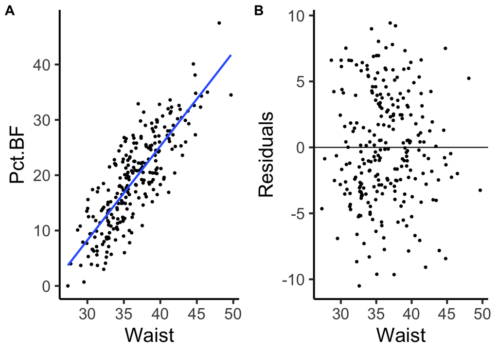

```r
p1 = ggplot(data,
aes(x = Waist, y = Pct.BF)) +
geom_point(size = 1) + theme_classic(base_size = 20) +geom_smooth(method = "lm", se = FALSE)

p11 = ggplot(data, aes(x = Waist, y = lresid)) +
geom_point(size = 1) + theme_classic(base_size = 20) +labs(y = "Residuals")+ geom_hline(yintercept = 0)

ggarrange(p1,p11, labels = c("A","B"), ncol = 2, nrow = 1)
```

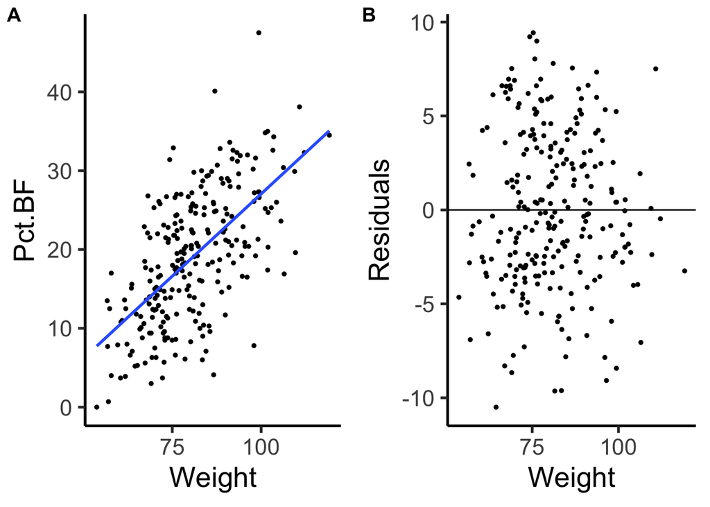

```r
p2 = ggplot(data, aes(x = Weight, y = Pct.BF)) +
geom_point(size = 1) + theme_classic(base_size = 20) +geom_smooth(method = "lm", se = FALSE)

p22 = ggplot(data, aes(x = Weight, y = lresid)) +
geom_point(size = 1) + theme_classic(base_size = 20) +labs(y = "Residuals")+ geom_hline(yintercept = 0)

ggarrange(p2,p22, labels = c("A","B"), ncol = 2, nrow = 1)
```

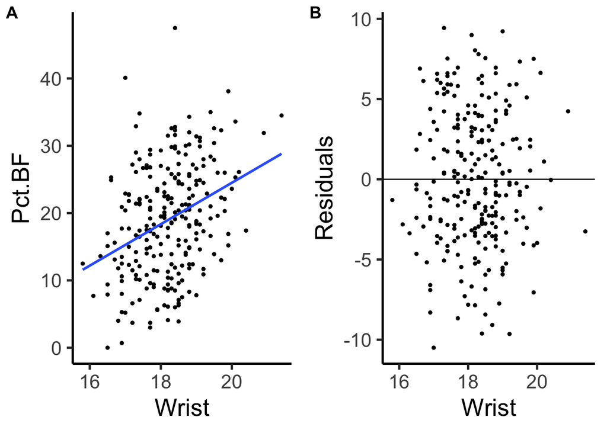

```r
p3 = ggplot(data,
aes(x = Wrist, y = Pct.BF)) +
geom_point(size = 1) + theme_classic(base_size = 20) +geom_smooth(method = "lm", se = FALSE)

p33 = ggplot(data, aes(x = Wrist, y = lresid)) +
geom_point(size = 1) + theme_classic(base_size = 20) +labs(y = "Residuals")+ geom_hline(yintercept = 0)

ggarrange(p3,p33, labels = c("A","B"), ncol = 2, nrow = 1)
```

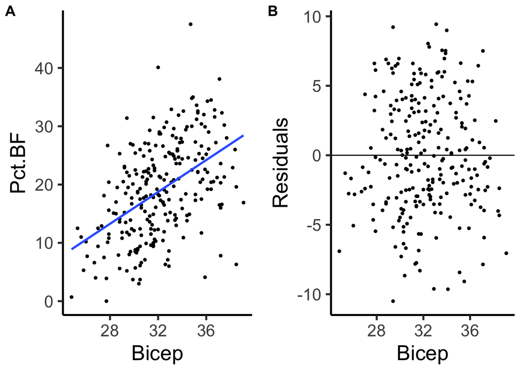

```r
p4 = ggplot(data,
aes(x = Bicep, y = Pct.BF)) +
geom_point(size = 1) + theme_classic(base_size = 20) +geom_smooth(method = "lm", se = FALSE)

p44 = ggplot(data, aes(x = Bicep, y = lresid)) +
geom_point(size = 1) + theme_classic(base_size = 20) +labs(y = "Residuals")+ geom_hline(yintercept = 0)

ggarrange(p4,p44, labels = c("A","B"), ncol = 2, nrow = 1)
```

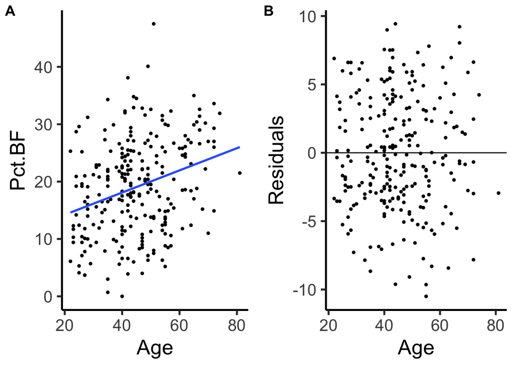

```r
p5 = ggplot(data,
aes(x = Age, y = Pct.BF)) +
geom_point(size = 1) + theme_classic(base_size = 20) +geom_smooth(method = "lm", se = FALSE)

p55 = ggplot(data, aes(x = Age, y = lresid)) +
geom_point(size = 1) + theme_classic(base_size = 20) +labs(y = "Residuals")+ geom_hline(yintercept = 0)

ggarrange(p5,p55, labels = c("A","B"), ncol = 2, nrow = 1)
```

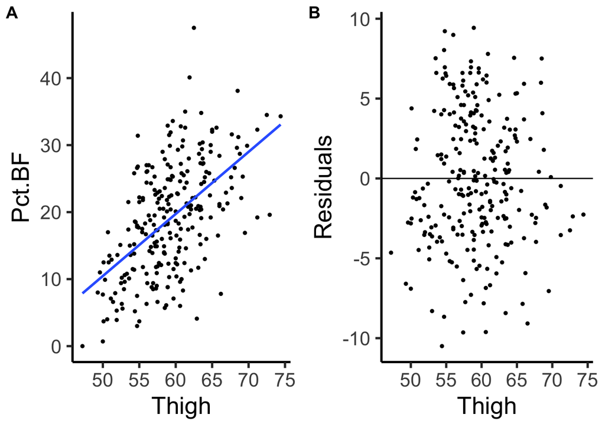

```r
p6 = ggplot(data,
aes(x = Thigh, y = Pct.BF)) +
geom_point(size = 1) + theme_classic(base_size = 20) +geom_smooth(method = "lm", se = FALSE)

p66 = ggplot(data, aes(x = Thigh, y = lresid)) +
geom_point(size = 1) + theme_classic(base_size = 20) +labs(y = "Residuals")+ geom_hline(yintercept = 0)

ggarrange(p6,p66, labels = c("A","B"), ncol = 2, nrow = 1)
```

## 2.12 Checking for Independece

Since the 250 samples are sampled from various ages and independently. We can assume that each of them are independent.

## 2.14 Checking for Normality

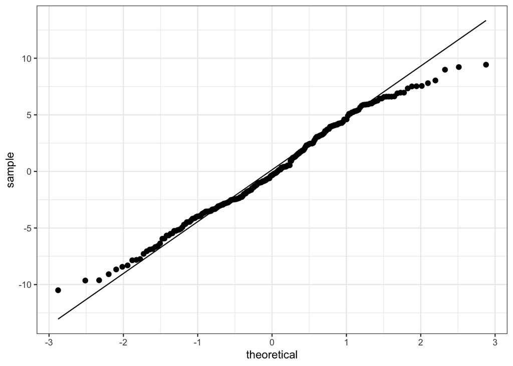

```r
data %>% ggplot()+aes(sample = lresid) + geom_qq(size = 2) + geom_qq_line() + theme_bw()
```

Apart from few points in the lower and upper tail, the majority of the points lie very close to the diagonal line in the QQ plot. Almost right on the diagonal line. Hence, the normality assumption for the residuals is well satisfied.

On the other hand, base on the Central Limit Theorem, the sample size is large enough that most of the point would follow the normal distribution. So we can run our test under the normal distribution assumption.